# [시험 2] 임원기_190701

```r
library(dplyr)
library(ggplot2)
library(car)
```

### **문제 1.**

#### 다음의 값을 R 내장함수를 이용하여 구하시오.

1. 시행횟수가 6이고 성공확률이 1/3인 이항분포에서 성공횟수가 3이 될 확률

```r
dbinom(3, size=6, prob=1/3)
```

```
## [1] 0.2194787
```

2. 평균이 170이고 표준편차가 6인 정규분포에서 상위20%가 되는 사람들의 키 범위

```r
z <- qnorm(0.8, mean=0, sd=1)
# z = x-u/sigam
X <- (z*6)+170

# 175cm 이상
```

3. 자유도가 3인 카이제곱분포에서 누적확률이 95%일 때의 값

```r
qchisq(0.95, df=3)
```

```
## [1] 7.814728
```

4. 자유도가 2인 t-분포에서 누적확률이 0.975일 떄의 값

```r
qt(0.975, df=2)
```

```
## [1] 4.302653
```

5. 표준정규분포에서 확률변수의 값이 1일 때의 누적확률

```r
pnorm(1, mean=0, sd=1)
```

```
## [1] 0.8413447
```

### **문제 2.**

#### 다음의 문항이 베르누이 시행인지 판단하시오.

1. 영화관에서 줄을 기다리는 시간을 측정한다 - 아니다
2. 전화가 왔을 때, 전화를 한 사람이 여자인지를 측정한다. - 맞다
3. 주사위를 한 번 던졌을 때, 나오는 숫자를 체크한다. - 아니다
4. 동전의 앞면이 위로 향하고 있는지 체크한다. - 맞다
5. 사람의 눈이 녹색인지 체크한다. - 맞다

### **문제 3.**

#### R 내장 데이터인 iris를 이용하여 setosa중 sepal.length의 모평균에 대한 95% 신뢰구간을 구하시오.

```r
ex3 <- iris %>% select(Sepal.Length, Species) %>% filter(Species == "setosa") # 데이터
n <- length(ex3$Sepal.Length) # 표본갯수
s <- sd(ex3$Sepal.Length) # 표본표준편차
x_bar <- mean(ex3$Sepal.Length) # 표본평균
alpha <- 0.05 # 유의수준
z <- qnorm(1-(alpha/2)) # 유의수준 5%에서 z값

( ll <- x_bar - z*s/sqrt(n) ) # 신뢰구간 하한
```

```
## [1] 4.908297
```

```r
( ul <- x_bar + z*s/sqrt(n) ) # 신뢰구간 상한
```

```
## [1] 5.103703
```

### **문제 4.**

#### 한 농구 선수가 자유투를 던지면 10번중에 7번을 성공한다고 할 때 다음을 풀이하시오.

X ~ B(10, 7/10)

1. 이 선수가 자유투를 10번 던져 9번 이상 성공할 확률

```r
1-pbinom(8, size=10, prob=7/10)
```

```
## [1] 0.1493083
```

2. 이 선수가 자유투를 10번 던질 때 5번 이상 8번 이하로 성공할 확률

```r
pbinom(8, size=10, prob=7/10) - pbinom(4, size=10, prob=7/10)
```

```
## [1] 0.8033427
```

### **문제 5.**

#### 한국인의 평균 알코올 섭취량이 8.1g이다 2008년 무작위로 뽑은 알코올 섭취량이 다음과 같다. 재작년과 달라졌다고 할 수 있나?

```
##
##  Shapiro-Wilk normality test
##
## data:  ex5
## W = 0.96287, p-value = 0.818
```

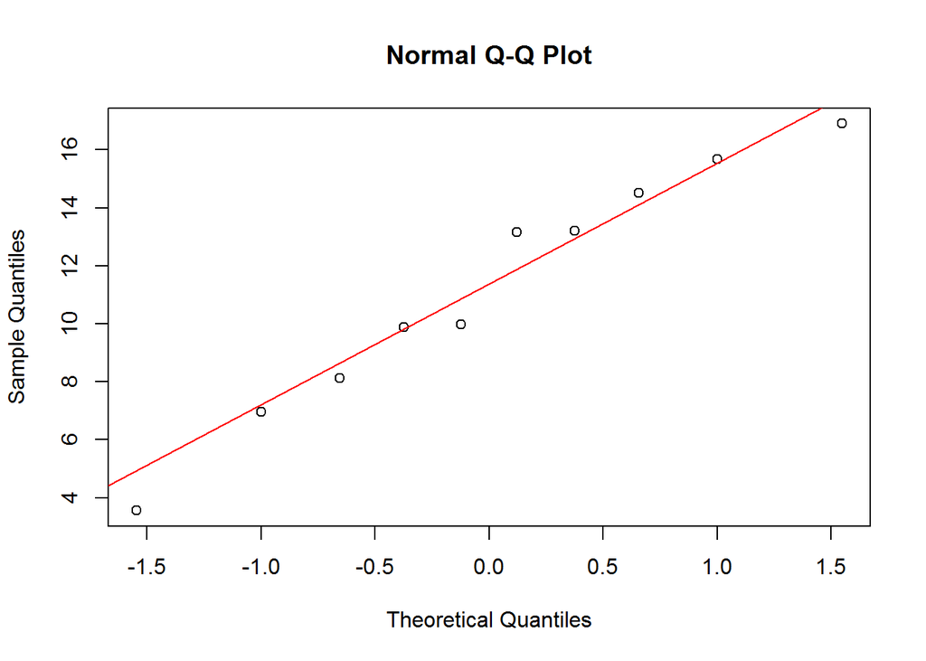

```r
ex5 <- c(16.9, 13.21, 15.67, 9.87, 13.15, 9.98, 3.56, 14.5, 8.12, 6.97)

# 0.정규성 검정
shapiro.test(ex5); qqnorm(ex5); qqline(ex5, col="red") # 정규성 검정결과 p-value 값이 0.818로 정규성을 만족한다.
```

```r
# 모분산을 모르고 소표본이므로 t-test 검정을 사용한다

# 가설
# H0 : mu = 8.1(g)
# H1 : mu != 8.1(g)

# 판정
t.test(ex5, mu=8.1, alternative = "two.sided")
```

```
##
##  One Sample t-test
##
## data:  ex5
## t = 2.3182, df = 9, p-value = 0.04562
## alternative hypothesis: true mean is not equal to 8.1
## 95 percent confidence interval:
##   8.174819 14.211181
## sample estimates:
## mean of x
##    11.193
```

```r
mean(ex5); sd(ex5)
```

```
## [1] 11.193
```

```
## [1] 4.219126
```

```r
# 결론
# t-test 검정걸과 2008년 한국인의 알코올 섭취량은 평균 11.193 ± 4.22로 나타났으며, p-value 값이 0.04562로 귀무가설을 기각한다.
# 즉, 2008년 한국인의 알코올 섭취량이 재작년에 비해 달라졌다고 할 수 있다.
```

### **문제 6.**

#### 정규분포에서 form <= X <= to의 확률을 구하는 함수를 작성하시오.

```r
rangenorm <- function(from, to, mean, sd){
  result <- pnorm(to, mean, sd) - pnorm(from, mean, sd)
  return(result)
}
rangenorm(-1.96, 1.96, 0, 1)
```

```
## [1] 0.9500042
```

### **문제 7.**

#### mpg데이터셋에서 다음을 검정해 보시오.

1. subcompact 자동차와 midsize 자동차의 도시연비

```r
library(ggplot2)
subcm <- dplyr::select(mpg, class, cty) %>% filter(class == "subcompact")
mid <- dplyr::select(mpg, class, cty) %>% filter(class == "midsize")


# 정규성 검정
par(mfrow=c(1,2))
shapiro.test(subcm$cty); qqnorm(subcm$cty); qqline(subcm$cty, col="red")
```

```
##
##  Shapiro-Wilk normality test
##
## data:  subcm$cty
## W = 0.91723, p-value = 0.01187
```

```
##
##  Shapiro-Wilk normality test
##
## data:  mid$cty
## W = 0.93251, p-value = 0.01751
```

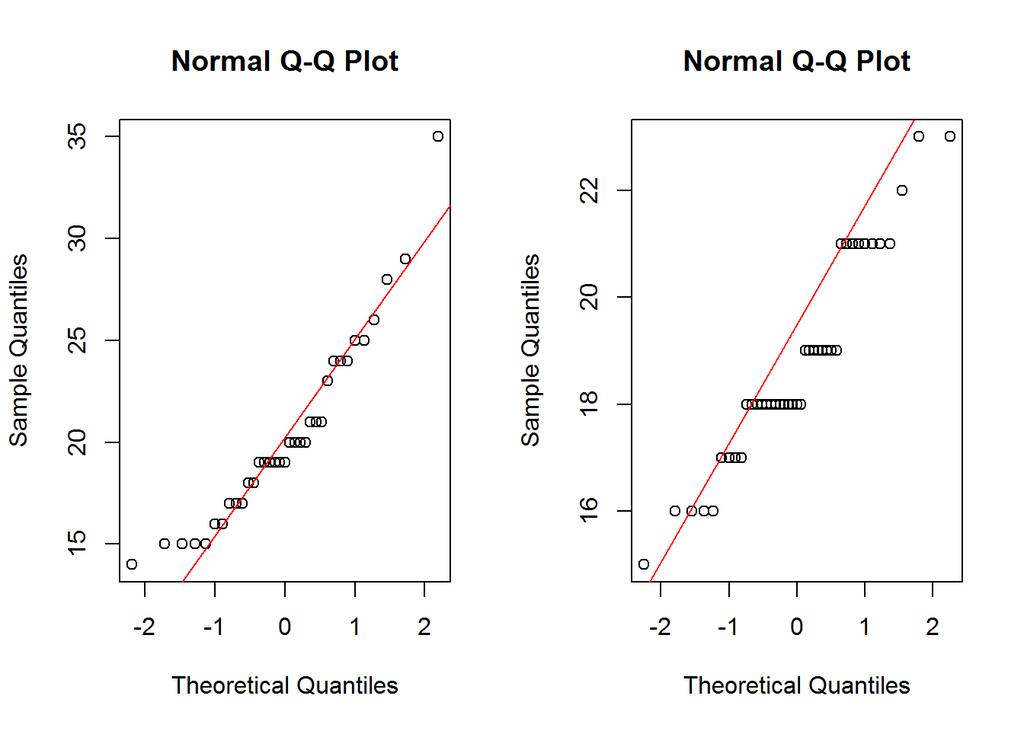

```r
shapiro.test(mid$cty); qqnorm(mid$cty); qqline(mid$cty, col="red")
```

```r
par(mfrow=c(1,1))

## 두 집단 모두 p-value 값이 유의수준 0.05보다 작아 정규성을 만족하지 않으므로 Wilcoxon 순위 검정을 시행
mpg_sub_mid <- filter(mpg, class %in% c("subcompact","midsize"))
str(mpg_sub_mid)
```

```
## Classes 'tbl_df', 'tbl' and 'data.frame':    76 obs. of  11 variables:
##  $ manufacturer: chr  "audi" "audi" "audi" "chevrolet" ...
##  $ model       : chr  "a6 quattro" "a6 quattro" "a6 quattro" "malibu" ...
##  $ displ       : num  2.8 3.1 4.2 2.4 2.4 3.1 3.5 3.6 3.8 3.8 ...
##  $ year        : int  1999 2008 2008 1999 2008 1999 2008 2008 1999 1999 ...
##  $ cyl         : int  6 6 8 4 4 6 6 6 6 6 ...
##  $ trans       : chr  "auto(l5)" "auto(s6)" "auto(s6)" "auto(l4)" ...
##  $ drv         : chr  "4" "4" "4" "f" ...
##  $ cty         : int  15 17 16 19 22 18 18 17 18 18 ...
##  $ hwy         : int  24 25 23 27 30 26 29 26 26 25 ...
##  $ fl          : chr  "p" "p" "p" "r" ...
##  $ class       : chr  "midsize" "midsize" "midsize" "midsize" ...
```

```r
# 가설설정
# H0 : mu1 == mu2
# H1 : mu1 != mu2

wilcox.test(mpg_sub_mid$cty ~ mpg_sub_mid$class)
```

```
##
##  Wilcoxon rank sum test with continuity correction
##
## data:  mpg_sub_mid$cty by mpg_sub_mid$class
## W = 588, p-value = 0.1748
## alternative hypothesis: true location shift is not equal to 0
```

```r
# 검정결과 p-value 값이 0.1748로 유의수준 0.05 하에서 귀무가설을 기각할만한 충분한 근거가 없다. 즉, subcompact 자동차와 midsize 자동차 간에 연비 차이는 없다.

## 두 집단이 정규성을 만족한다는 가정하에 모수적 방법(t-test)으로 검정

# 가설설정
# H0 : mu1 == mu2
# H1 : mu1 != mu2

# 등분산성 검정
var.test(mpg_sub_mid$cty ~ mpg_sub_mid$class)
```

```
##
##  F test to compare two variances
##
## data:  mpg_sub_mid$cty by mpg_sub_mid$class
## F = 0.17888, num df = 40, denom df = 34, p-value = 5.201e-07
## alternative hypothesis: true ratio of variances is not equal to 1
## 95 percent confidence interval:
##  0.09194321 0.34194788
## sample estimates:
## ratio of variances
##          0.1788836
```

```r
# 등분산성 검정결과 p-value 값이 유의수준 0.05보다 작으므로 등분산성 가정이 성립되지 않는다. 따라서 이분산을 가정한 t-test를 실시한다.


# 이분산 t-test 검정
t.test(mpg_sub_mid$cty ~ mpg_sub_mid$class, mu=0, alternative = "two.sided", var.equal=F)
```

```
##
##  Welch Two Sample t-test
##
## data:  mpg_sub_mid$cty by mpg_sub_mid$class
## t = -1.934, df = 44.299, p-value = 0.05952
## alternative hypothesis: true difference in means is not equal to 0
## 95 percent confidence interval:
##  -3.29829641  0.06763439
## sample estimates:
##    mean in group midsize mean in group subcompact
##                 18.75610                 20.37143
```

```r
mean(subcm$cty); sd(subcm$cty)
```

```
## [1] 20.37143
```

```
## [1] 4.602338
```

```r
mean(mid$cty); sd(mid$cty)
```

```
## [1] 18.7561
```

```
## [1] 1.946542
```

```r
# 검정결과, 사이즈가 subcompact인 차량의 평균 연비와 표준편차는 20.3714 ± 4.60 이고
# midsize인 차량의 평균 연비와 표준편차는 18.7561 ± 1.946로 나타났으며
# p-value 값이 0.05952로 유의수준 0.05하에서 귀무가설을 기각할만한 충분한 근거가 없다. 즉, subcompact 자동차와 midsize 자동차의 연비 차이는 없다.
```

2. 일반 휘발유(r)와 고급 휘발유(p)의 고속도로 연비

```r
r <- dplyr::select(mpg, fl, hwy) %>% filter(fl == "r")
p <- dplyr::select(mpg, fl, hwy) %>% filter(fl == "p")

# 정규성 검정
par(mfrow=c(1,2))
shapiro.test(r$hwy); qqnorm(r$hwy); qqline(r$hwy, col="red")
```

```
##
##  Shapiro-Wilk normality test
##
## data:  r$hwy
## W = 0.93578, p-value = 7.603e-07
```

```
##
##  Shapiro-Wilk normality test
##
## data:  p$hwy
## W = 0.84551, p-value = 8.341e-06
```

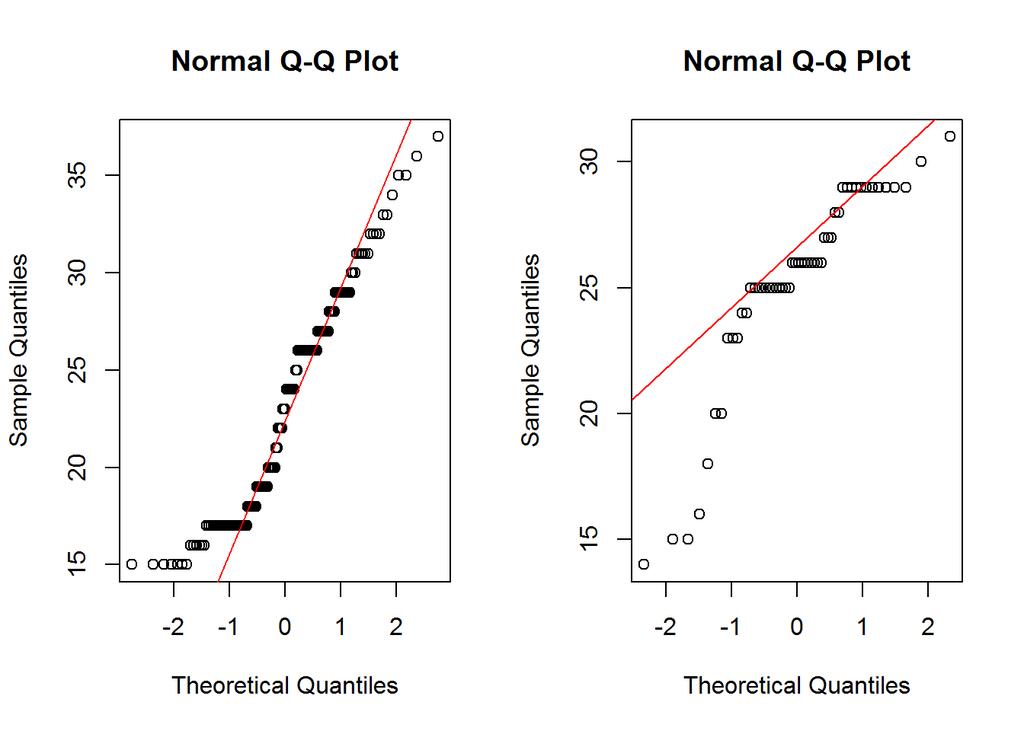

```r
shapiro.test(p$hwy); qqnorm(p$hwy); qqline(p$hwy, col="red")
```

```r
par(mfrow=c(1,1))

#정규성 검정결과 두 집단 모두 정규성을 만족하지 않는다. 따라서 비모수적 방법을 이용한 검정을 사용한다.

mpg_r_p <- filter(mpg, fl %in% c("r","p"))  # fl(연료종류)가 r(일반휘발유)과 p(고급휘발유)인 데이터만 추출

# 가설설정
# H0 : mu1 == mu2
# H1 : mu1 != mu2

wilcox.test(mpg_r_p$hwy ~ mpg_r_p$fl)
```

```
##
##  Wilcoxon rank sum test with continuity correction
##
## data:  mpg_r_p$hwy by mpg_r_p$fl
## W = 5420, p-value = 0.008495
## alternative hypothesis: true location shift is not equal to 0
```

```r
# 윌콕스 순위검정 결과 p-value값이 0.008495로 유의수준 0.05하에서 귀무가설이 기각된다. 즉, 휘발유 종류에 따른 고속도로 연비 차이가 있는 것으로 판단된다.

## 두 집단이 정규성을 만족한다는 가정하에 모수적 방법(t-test)으로 검정

# 가설설정
# H0 : mu1 == mu2
# H1 : mu1 != mu2

# 등분산성 검정
var.test(mpg_r_p$hwy ~ mpg_r_p$fl)
```

```
##
##  F test to compare two variances
##
## data:  mpg_r_p$hwy by mpg_r_p$fl
## F = 0.51064, num df = 51, denom df = 167, p-value = 0.006139
## alternative hypothesis: true ratio of variances is not equal to 1
## 95 percent confidence interval:
##  0.3353372 0.8204816
## sample estimates:
## ratio of variances
##          0.5106396
```

```r
# 등분산성 검정 결과 p-value값이 0.006139로 유의수준 0.05하에서 등분산성이 성립되지 않는다. 따라서 이분산을 가정한 t-test를 시행한다.

# 이분산 t-test 검정
t.test(mpg_r_p$hwy ~ mpg_r_p$fl, mu=0, alternative = "two.sided", var.equal=F)
```

```
##
##  Welch Two Sample t-test
##
## data:  mpg_r_p$hwy by mpg_r_p$fl
## t = 3.2352, df = 118.29, p-value = 0.001576
## alternative hypothesis: true difference in means is not equal to 0
## 95 percent confidence interval:
##  0.8676632 3.6057800
## sample estimates:
## mean in group p mean in group r
##        25.23077        22.99405
```

```r
mean(r$hwy); sd(r$hwy)
```

```
## [1] 22.99405
```

```
## [1] 5.50503
```

```r
mean(p$hwy); sd(p$hwy)
```

```
## [1] 25.23077
```

```
## [1] 3.933842
```

```r
# 검정결과 일반휘발유의 고속도로 연비의 평균과 표준편차는 22.9940 ± 5.505,
# 고급휘발유의 고속도로 연비의 평균과 표준편차는 25.2307 ± 3.9338로 나타났으며,
# p-value값이 0.001576으로 유의수준 0.05 하에서 귀무가설을 기각한다. 즉, 휘발유 종류에 따른 고속도로연비는 차이가 있는 것으로 판단된다.
```